# Almost a Quarter Century later: How 9/11 Lives On in America’s Collective Memory Karim K. Kardous

- Show All Code
- Hide All Code
- View Source

## *Prelude*

**About the data/article in a nutshell:** This ambitious Pew Research piece examines the enduring legacy of 9/11 on American public opinion over two decades, tracking how the attacks created lasting collective memories for those old enough to remember when the unimaginable happened, briefly unified the nation in patriotic sentiment and trust in government, sparked initial support for military action that later waned, and reshaped views on terrorism, civil liberties, and Muslims in America. I chose 4 plots to display, as the article itself has a total of 11 plots. I think what guided my decision to choose only 4 is the uniqueness of the plots chosen. I also think each of one of the said plots conveyed a different message, whether related to the impact, chronology of said impact, or its impact on the political spectrum.  
If you like to give it a read (free), feel free to click [here](https://www.pewresearch.org/politics/2021/09/02/two-decades-later-the-enduring-legacy-of-9-11/).

**Overall Strategy for building first plot:** The data for first plot shows the % of people who remember where they were/what they were doing when they heard the the news.  
Since there are many points plotted (> 50), I took a snippet of the plot area and uploaded it to a free service/website I had not heard about before: [WebPlotDigitizer](https://web.eecs.utk.edu/~dcostine/personal/PowerDeviceLib/DigiTest/index.html)  
I then used the manual option to ‘add points’ before viewing the data and copying and pasting it below; note that those are x and y coordinates. I finally normalized the data to get the actual values (or a very close approximation); that is age (X-axis) against percentage (Y-axis).  
Below is the snippet of that last step. Since the relationship isn’t linear, hence not able to use the rule of three/cross multiply, the values were generated after normalizing the coordinates in relation with both age and %.  
Below is the snippet of the software generating said coordinates.

[figure not shown]

## **A Powerful Memory**

Below I show the first 10 rows, with the first two columns showing the raw pull from WebPlotDigitizer while the next two show the normalized data; suitable to graph and match (as closely as possible) the article’s.

```r
library(tidyverse)
library(patchwork)
library(showtext)
library(janitor)
library(cowplot)
library(ggtext)
library(gt)
library(cowplot)

theme_set_custom <- function() {
  # loading google fonts
  sysfonts::font_add_google("Libre Franklin", "franklin")

  # using here::here() to get absolute path, and check if file exists first
  font_path <- "../../renv/library/macos/R-4.5/aarch64-apple-darwin20/sysfonts/fonts/Libre_Franklin/static/LibreFranklin-Medium.ttf"

  if (file.exists(font_path)) {
    sysfonts::font_add(family = "franklin-medium", regular = font_path)
  } else {
    # Fallback to Google Fonts version
    sysfonts::font_add_google("Libre Franklin", "franklin-medium")
  }

  showtext::showtext_auto()

  # applying ggplot2 theme
  ggplot2::theme_set(
    ggplot2::theme_minimal(base_family = "franklin") +
      ggplot2::theme(
        panel.background = ggplot2::element_rect(fill = "#f8f8f8", color = NA),
        plot.background = ggplot2::element_rect(fill = "#f8f8f8", color = NA)
      )
  )
}
theme_set_custom()

gt_nyt_custom <- function(x, title = '', subtitle = '', first_10_rows_only = TRUE){

  x <- x |> clean_names(case = 'title')
  numeric_cols <- x |> select(where(is.double)) |> names()
  integer_cols <- x |> select(where(is.integer)) |> names()

  title_fmt <- if(title != "") glue::glue("**{title}**") else ""
  subtitle_fmt <- if(subtitle != "") glue::glue("*{subtitle}*") else ""

  x |>
    (\(x) if (first_10_rows_only) slice_head(x, n = 10) else x)() |>
    gt() |>
    tab_header(
      title = md(title_fmt),
      subtitle = md(subtitle_fmt)
    ) |>
    tab_style(
      style = list(
        cell_text(color = '#333333')
      ),
      locations = cells_body()
    ) |>
    tab_style(
      style = list(
        cell_text(color = '#CC6600', weight = 'bold')
      ),
      locations = cells_column_labels(everything())
    ) |>
    fmt_number(
      columns = c(numeric_cols),
      decimals = 1
    ) |>
    fmt_number(
      columns = c(integer_cols),
      decimals = 0
    ) |>
    tab_options(
      table.font.names = c("Merriweather", "Georgia", "serif"),
      table.font.size = 14,
      heading.title.font.size = 18,
      heading.subtitle.font.size = 14,
      column_labels.font.weight = "bold",
      column_labels.background.color = "#eeeeee",
      table.border.top.color = "#dddddd",
      table.border.bottom.color = "#dddddd",
      data_row.padding = px(6),
      row.striping.include_table_body = TRUE,
      row.striping.background_color = "#f9f9f9"
    )

}
# paste in data from WebPlotDigitizer
coords_data <- read.table(
  text = "45.6808988764045, 295.838202247191
  52.20674157303371, 262.66516853932586
  58.73258426966292, 230.03595505617977
  65.25842696629213, 208.28314606741574
  71.78426966292135, 183.2674157303371
  78.31011235955056, 172.39101123595506
  84.83595505617977, 169.12808988764044
  91.361797752809, 164.23370786516855
  97.88764044943821, 164.23370786516855
  103.86966292134832, 161.51460674157303
  110.39550561797753, 158.79550561797754
  116.92134831460675, 155.53258426966292
  123.44719101123596, 153.35730337078652
  129.97303370786517, 155.53258426966292
  136.49887640449438, 156.07640449438202
  142.4808988764045, 161.51460674157303
  149.0067415730337, 161.51460674157303
  156.07640449438202, 161.51460674157303
  162.60224719101123, 164.23370786516855
  168.58426966292134, 161.51460674157303
  175.11011235955056, 161.51460674157303
  181.63595505617977, 161.51460674157303
  188.16179775280898, 161.51460674157303
  194.6876404494382, 156.07640449438202
  200.6696629213483, 153.35730337078652
  207.73932584269664, 147.9191011235955
  214.26516853932586, 147.3752808988764
  220.24719101123597, 150.0943820224719
  226.22921348314608, 150.638202247191
  233.2988764044944, 150.0943820224719
  239.8247191011236, 153.35730337078652
  246.35056179775282, 155.53258426966292
  252.87640449438203, 161.51460674157303
  258.85842696629214, 158.25168539325844
  265.3842696629213, 156.07640449438202
  271.91011235955057, 156.07640449438202
  278.9797752808989, 158.25168539325844
  284.961797752809, 150.638202247191
  291.48764044943823, 150.638202247191
  298.0134831460674, 150.638202247191
  304.53932584269666, 147.3752808988764
  311.06516853932584, 141.9370786516854
  317.5910112359551, 144.6561797752809
  323.5730337078652, 141.9370786516854
  330.0988764044944, 144.6561797752809
  336.6247191011236, 144.6561797752809
  343.1505617977528, 144.6561797752809
  349.67640449438204, 150.638202247191
  356.2022471910112, 150.0943820224719
  362.72808988764046, 153.35730337078652
  368.7101123595506, 153.35730337078652
  375.7797752808989, 156.07640449438202
  381.761797752809, 152.81348314606743
  388.2876404494382, 156.07640449438202
  394.8134831460674, 150.638202247191
  401.3393258426966, 158.79550561797754",
  sep = ",",
  col.names = c("x", "y")
  )

# assign lower-upper bounds for both age and %
age_min <- 25
age_max <- 80
percent_min <- 42
percent_max <- 99

# get lower-upper bounds for coordinates as well
x_pixel_min <- min(coords_data$x)
x_pixel_max <- max(coords_data$x)
y_pixel_min <- min(coords_data$y)
y_pixel_max <- max(coords_data$y)

# normalize/transform coordinates to actual plot values/data
memory_data <-
  coords_data |>
  mutate(
    age = floor( age_min + (x - x_pixel_min) * (age_max - age_min) / (x_pixel_max - x_pixel_min) ),
    percentage = round( percent_max - (y - y_pixel_min) * (percent_max - percent_min) / (y_pixel_max - y_pixel_min), 1 )
  ) |>
  arrange(age, desc(x)) |>
  group_by(age) |>
  mutate(
    age_adj = if_else(row_number() > 1, age + 1, age)
    ) |>
  ungroup()

# there are missing ages, distinct() alone or even coupled with row_number() do not suffice
# map which ages are missing from current range of values
missing_ages <- setdiff(25:80, memory_data|> pull(age_adj))

# apply mapping using lead values as helpers
memory_data_cleaned <-
  memory_data |>
  arrange(desc(x)) |>
  mutate(
    lagged_age_adj = case_when(
      age_adj == lead(age_adj, order_by = age) ~ 1,
      TRUE ~ 0
    ),
    age_adj = coalesce(age_adj + lagged_age_adj, age),
    age_adj_final = case_when(
      is.na(age_adj + lagged_age_adj) ~ 80,
      age_adj + lagged_age_adj == 42 & lagged_age_adj == 1 ~ 41,
      age_adj + lagged_age_adj == 54 & lagged_age_adj == 1 ~ 53,
      TRUE ~ age_adj + lagged_age_adj
    )
  ) |>
  mutate(
    color_code = if_else(age_adj_final %in% c(25, 80), '#000000', '#D4AF37')
  ) |>
  select(
    x, y, age = age_adj_final, percentage, color_code
    ) |>
  arrange(age)

# check that all ages are mapped
# setdiff(25:80, memory_data_cleaned$age) ## all ages are mapped

memory_data_cleaned |>
  gt_nyt_custom(title = 'First 10 Records post Normalization')
```

**First 10 Records post Normalization**

| X | Y | Age | Percentage | Color Code |
| --- | --- | --- | --- | --- |
| 45.7 | 295.8 | 25.0 | 42.0 | #000000 |
| 52.2 | 262.7 | 26.0 | 54.3 | #D4AF37 |
| 58.7 | 230.0 | 27.0 | 66.4 | #D4AF37 |
| 65.3 | 208.3 | 28.0 | 74.4 | #D4AF37 |
| 71.8 | 183.3 | 29.0 | 83.7 | #D4AF37 |
| 78.3 | 172.4 | 30.0 | 87.7 | #D4AF37 |
| 84.8 | 169.1 | 31.0 | 88.9 | #D4AF37 |
| 91.4 | 164.2 | 32.0 | 90.7 | #D4AF37 |
| 103.9 | 161.5 | 33.0 | 91.7 | #D4AF37 |
| 97.9 | 164.2 | 34.0 | 90.7 | #D4AF37 |

```r
# work stats for first plot
title <- '**9/11 a powerful memory for Americans – but only for <br> adults old enough to remember**'
subtitle <- '*% who say they remember exactly where they were or what they were doing <br> the moment they heard the news about the Sept. 11 attacks*'
caption <- c(
  'Note: Data shown for individual ages based on rolling five-year average by age.<br>
   Source: Survey of U.S. adults conducted Aug. 23-29, 2021.<br><br>
   <span style="color:black;"><b>PEW RESEARCH CENTER/K.Kardous</b></span>'
)

main_plot_label <- '**93%** of those 30 and <br> older say they remember <br> exactly where they were <br> on Sept.11, 2001.'
label_for_youngest <- '42% of those age 25'
label_for_oldest <- '92% of those ages 80+'

p1 <- memory_data_cleaned |>
  ggplot(aes(x = age, y = percentage, color = I(color_code))) +
  geom_point(fill = '#D4AF37', shape = 21, size = 2) +
  coord_cartesian(ylim = c(0, 100), xlim = c(25, 81), clip = "off") +
  scale_x_continuous(
    breaks = c(25, 30, 35, 40, 45, 50, 55, 60, 65, 70, 75, 80),
    labels = c("", "", "", "", "", "", "", "", "", "", "", ""),  # we keep them blank and add a geom_text layer for added flexibility/customizability
    minor_breaks = seq(25, 80, 1),
    sec.axis = dup_axis(), # this is neeed to create a duplicated x axis before moving it to the top of plot
    expand = c(0.03, 0.01)
  )  +
  scale_y_continuous(
    breaks = seq(0, 100, 10),
    expand = c(0, 0),
    labels = c(as.character(seq(0, 90, 10)), ' ')
    ) +
  labs(
    x = element_blank(),
    y = element_blank(),
    title = title,
    subtitle = subtitle,
    caption = caption
  ) +
  geom_text(
  data = tibble(
    x = c(30, 35, 40, 45, 50, 55, 60, 65, 70, 75, 80),
    labels = c("30", "35", "40", "45", "50", "55", "60", "65", "70", "75", "80+")
  ),
  aes(x = x, y = 109, label = labels),
  inherit.aes = FALSE,
  color = "grey50",
  size = 3
  ) +
  geom_segment(
    data = tibble(x = seq(26, 79, 1)),
    aes(x = x, xend = x, y = 105.5, yend = 103),
    inherit.aes = FALSE,
    color = "grey50",
    linewidth = .2
  ) +
  geom_segment(
    data = tibble(
      x = c(25, 30, 35, 40, 45, 50, 55, 60, 65, 70, 75, 80)
      ),
    aes(x = x, xend = x, y = 107, yend = 103),
    inherit.aes = FALSE,
    color = "grey50",
    linewidth = .2
  ) +
  geom_label(
    x = 22, y = 100,
    label.size = NA,
    fill = "#f8f8f8",
    label = '100%',
    color = 'grey50'
  ) +
  geom_label(
    x = 23.4, y = 109,
    label.size = NA,
    fill = "#f8f8f8",
    label = '  Age 25',
    color = 'grey50',
    size = 3
  ) +
  # main plot label
  geom_richtext(
    hjust = 0,
    x = 51, y = 50.5,
    label = main_plot_label,
    fill = "#f8f8f8",
    color = 'black',
    size = 4,
    label.r = unit(0, "pt"),
    label.padding = unit(c(0.5, 0.5, 0.5, 0.5), "lines")
  ) +
  # yongest age label
  geom_text(
    x = 32.67,
    y = 46,
    label = label_for_youngest,
    colour = '#D4AF37'
  ) +
  geom_segment(
    x = 26.5, xend = 26.5,
    y = 43, yend = 41.4,
    linewidth = .2,
    color = 'grey20'
    ) +
  geom_segment(
    x = 26.5, xend = 25.3,
    y = 41.5, yend = 41.5,
    linewidth = .2,
    color = 'grey20'
    ) +
  # oldest age label
  geom_text(
    x = 73.3,
    y = 84,
    label = label_for_oldest,
    colour = '#D4AF37'
  ) +
  geom_segment(
    x = 80, xend = 80,
    y = 91.5, yend = 86,
    linewidth = .2,
    color = 'grey20'
    ) +
  theme(
    plot.title.position = 'plot',
    plot.caption.position = 'plot',
    plot.caption = element_markdown(
      color = 'grey50',
      size = 10.5,
      hjust = 0,
      lineheight = 1.2,
      margin = margin(t = 0, b = .1, unit = 'cm')
      ),
    plot.title = element_markdown(
      face = 'bold',
      size = 16
      ),
    plot.subtitle = element_markdown(
      size = 12,
      color = 'grey50',
      lineheight = 1.25,
      margin = margin(t = 0.3, b = .3, unit = 'cm')
      ),
    panel.grid.major.x = element_blank(),
    panel.grid.minor = element_blank(),
    # remove default axis elements
    axis.ticks.x.top = element_blank(),
    axis.ticks.x.bottom = element_blank(),
    axis.text.x.bottom = element_blank(),
    axis.line.x.top = element_blank(),
    axis.line.x.bottom = element_blank(),
    axis.text.y = element_text(color = "grey50"),
    # style the top labels
    axis.text.x.top = element_text(
      margin = margin(b = 0.4, unit = "cm"),
      color = "grey50",
      size = 9
      ),
    panel.grid.major = element_line(
      linetype = 2, colour = 'grey50', size = .2
      )
    )
```

The plot gets displayed below. Note that I added my name right after the source of the data (in the caption) only because while this is a replication from PEW Research Center, the data created doesn’t *exactly* match the data used in the article, for the vast majority they do, and when they don’t, they are within a reasonable/low spread.  
Crucially, the message conveyed in the plot stays the same: there is a generational ‘spread’ in impact on American collective memory regarding 9/11: 93% of those ages 30+ have a vivid memory of the moment they heard the news while *only* 42% of their ‘age 25’ counterparts share this experience. 42% is still surprisingly high in my opinion given that we are talking about an event that happened when that age group was 4-5 years old.

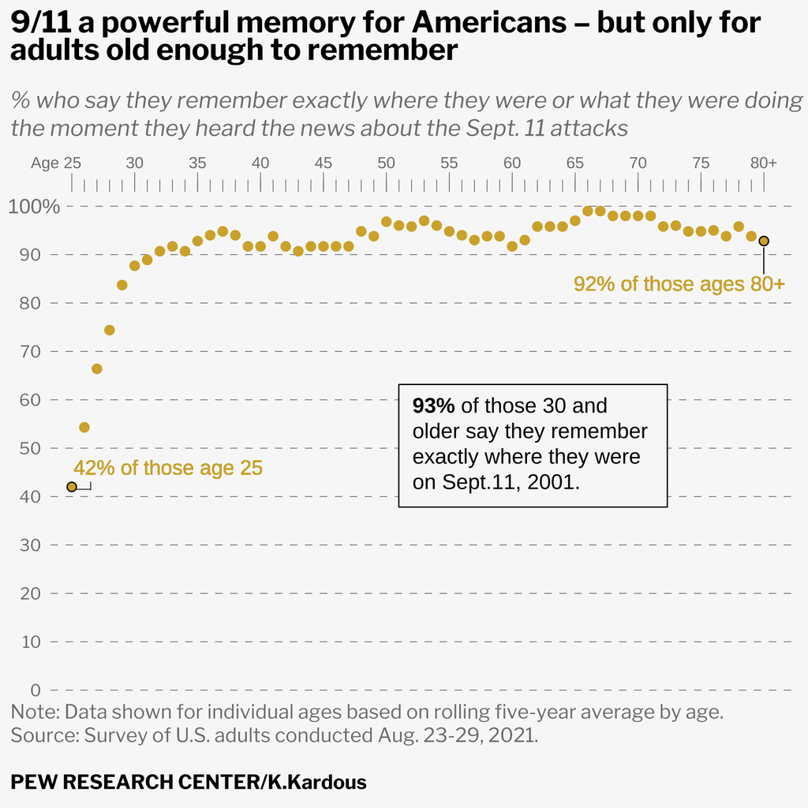

Overall, I like the design of the plot. I especially appreciated moving the x axis to the top along with its ‘ruler’ like design as the vast majority of the data sits on the upper region of the plot. I also like the fact that they added a label ‘aggregating’ the % for those 30 and above, simultaneously giving the reader a better picture of the dynamic while also utilizing an otherwise ‘dead’ area in the plot.